# Reproducible Research: Peer Assessment 1

## load libraries

```r
library(readr)
library(ggplot2)
library(party)
library(reshape2)
library(dplyr)
```

## Loading and preprocessing the data

Load data into correct format

- Check if activity.csv already exists, unpack if necessary
- using read_csv import data with correct data types
- look at the head of the data and summary to figure out basics

```r
if (!file.exists("./activity.csv"))
{
        unzip("./activity.zip")
}
activity <- read_csv("activity.csv", col_types = cols(date = col_date(format = "%Y-%m-%d"),
    steps = col_number()))
head(activity)
```

```
## # A tibble: 6 x 3
##   steps date       interval
##   <dbl> <date>        <dbl>
## 1    NA 2012-10-01        0
## 2    NA 2012-10-01        5
## 3    NA 2012-10-01       10
## 4    NA 2012-10-01       15
## 5    NA 2012-10-01       20
## 6    NA 2012-10-01       25
```

```r
summary(activity)
```

```
##      steps             date               interval
##  Min.   :  0.00   Min.   :2012-10-01   Min.   :   0.0
##  1st Qu.:  0.00   1st Qu.:2012-10-16   1st Qu.: 588.8
##  Median :  0.00   Median :2012-10-31   Median :1177.5
##  Mean   : 37.38   Mean   :2012-10-31   Mean   :1177.5
##  3rd Qu.: 12.00   3rd Qu.:2012-11-15   3rd Qu.:1766.2
##  Max.   :806.00   Max.   :2012-11-30   Max.   :2355.0
##  NA's   :2304
```

Provide a guick look at steps destibution:

- by interval
- day
- both

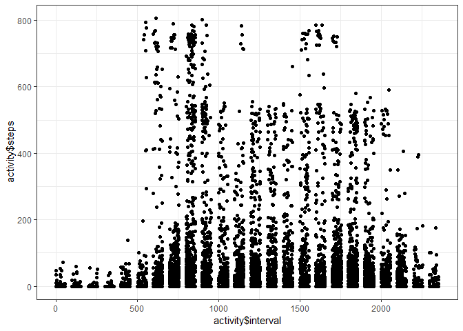

```r
qplot(activity$interval,activity$steps)+theme_bw()
```

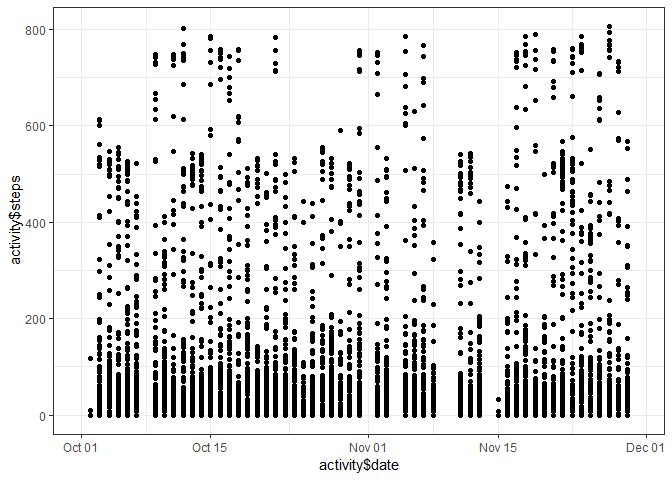

```r
qplot(activity$date,activity$steps)+theme_bw()
```

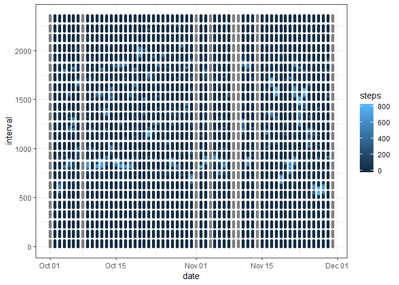

```r
x <- ggplot(data = activity, mapping = aes(x=date, y=interval, col=steps))
x+geom_point()+theme_bw()
```

## What is mean total number of steps taken per day?

For this part of the assignment, you can ignore the missing values in the dataset.

1. Make a histogram of the total number of steps taken each day
2. Calculate and report the mean and median total number of steps taken per day

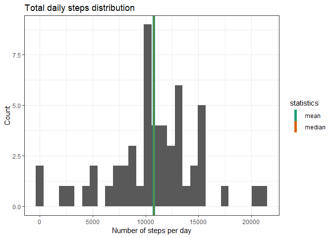

```r
daysteps<- aggregate(steps ~ date, activity, sum)
plotsteps <- function(daysteps) {
  ggplot(daysteps, aes(x=steps))+
          geom_histogram()+labs(x="Number of steps per day", y="Count", title = "Total daily steps distribution")+
          geom_vline(aes(xintercept=mean(daysteps$steps, na.rm = TRUE), color="mean"), show.legend=TRUE, size=2)+
          geom_vline(aes(xintercept=median(daysteps$steps, na.rm = TRUE), color="median"), show.legend=TRUE)+
          scale_color_brewer(name="statistics", palette = "Dark2")+theme_bw()
}
plotsteps(daysteps)
```

```r
mean(daysteps$steps, na.rm = TRUE)
```

```
## [1] 10766.19
```

```r
median(daysteps$steps, na.rm = TRUE)
```

```
## [1] 10765
```

## What is the average daily activity pattern?

1. Make a time series plot (i.e. type = “l”) of the 5-minute interval (x-axis) and the average number of steps taken, averaged across all days (y-axis)

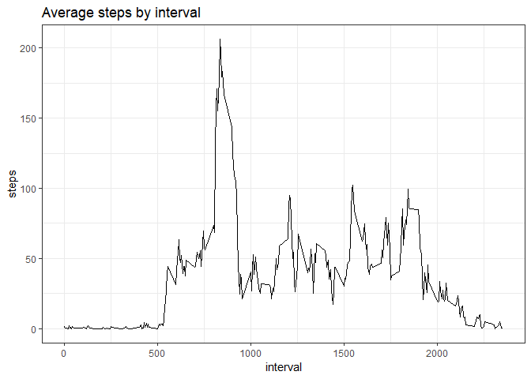

```r
intervalsteps<- aggregate(steps ~ interval, activity, mean)
ggplot(data=intervalsteps, aes(x=interval, y=steps))+theme_bw()+geom_line()+
        labs(title = "Average steps by interval")
```

2. Which 5-minute interval, on average across all the days in the dataset, contains the maximum number of steps?

```r
intervalsteps[which.max(intervalsteps$steps),1]
```

```
## [1] 835
```

Bonus - comparison on average steps for interval with predicted average steps based on desision tree model.

```r
activityclear <- na.omit(activity)
activityclear$datenum <- as.numeric(activityclear$date)
activityclear <- activityclear[,-2]

cfit1 <- ctree(steps ~ ., data = activityclear[,-3])
activityclear$pred <- predict(cfit1,activityclear)

intervalsteps$pred <- predict(cfit1,intervalsteps)
interval_long <- melt(intervalsteps, id = "interval")  # convert to long format
```

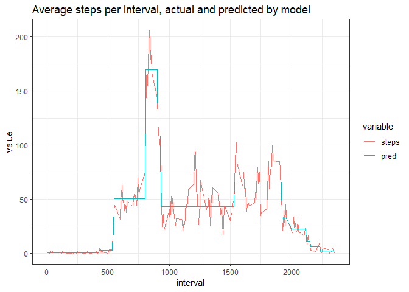

```r
ggplot(interval_long, aes(x = interval, y = value, colour = variable)) +
        theme_bw()+geom_line()+labs(title = "Average steps per interval, actual and predicted by model")
```

## Imputing missing values

Note that there are a number of days/intervals where there are missing values (coded as NA). The presence of missing days may introduce bias into some calculations or summaries of the data.

1. Calculate and report the total number of missing values in the dataset (i.e. the total number of rows with NAs)

```r
ok <- complete.cases(activity)
sum(!ok) #number of rows with NAs
```

```
## [1] 2304
```

2. Devise a strategy for filling in all of the missing values in the dataset. For a presious part of the task i estimated step numbers based on intervals using Conditional Inference Trees. I will be using the result of this prediction here (cfit1). Predictions for an interval based on its number are potte below. For a missing value in a given interval values from the plot below will be used

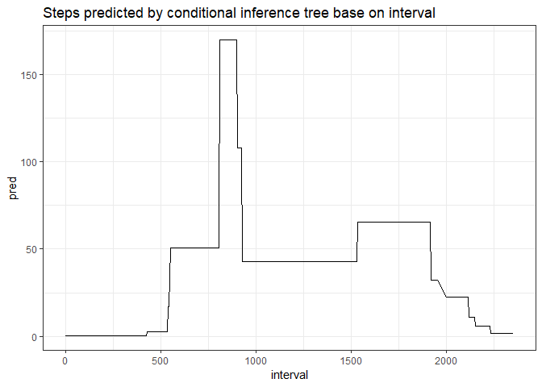

```r
ggplot(intervalsteps, aes(x = interval, y = pred)) + theme_bw()+geom_line()+
        labs(title = "Steps predicted by conditional inference tree base on interval")
```

3. Create a new dataset that is equal to the original dataset but with the missing data filled in.

```r
activityfixed <- activity %>%   mutate(pred = predict(cfit1, .)) %>% mutate(steps = ifelse(is.na(steps), pred, steps))
```

4. Make a histogram of the total number of steps taken each day and Calculate and report the mean and median total number of steps taken per day. Do these values differ from the estimates from the first part of the assignment? What is the impact of imputing missing data on the estimates of the total daily number of steps?

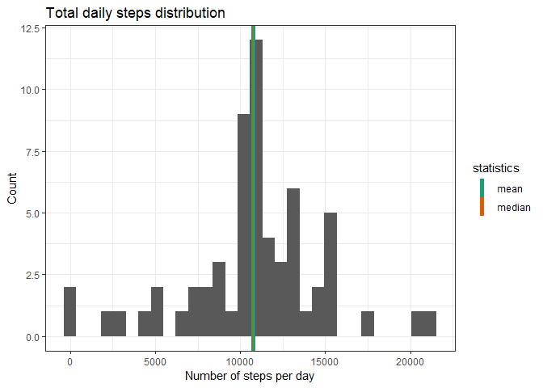

```r
daystepsfix<- aggregate(steps ~ date, activityfixed, sum)

plotsteps(daystepsfix)
```

```r
meanstepsfix<- mean(daystepsfix$steps, na.rm = TRUE)
mediandaystepsfix<- median(daystepsfix$steps, na.rm = TRUE)
```

Mean (10766.19) is the same, median (10766.19)is within 2 steps per day from the unprocessed activity data.

## Are there differences in activity patterns between weekdays and weekends?

For this part the weekdays() function may be of some help here. Use the dataset with the filled-in missing values for this part.

1. Create a new factor variable in the dataset with two levels – “weekday” and “weekend” indicating whether a given date is a weekday or weekend day.

```r
summary(as.POSIXlt(activityfixed$date)$wday)
```

```
##    Min. 1st Qu.  Median    Mean 3rd Qu.    Max.
##       0       1       3       3       5       6
```

```r
activityfixed <-
        activityfixed %>%   mutate(weekday = ifelse(
        as.POSIXlt(activityfixed$date)$wday == 0 |
        as.POSIXlt(activityfixed$date)$wday == 6,
        "weekend",
        "weekday"
        ))
activityfixed <- activityfixed %>% mutate(weekday = factor(weekday))
intervalsteps_fix<- aggregate(steps ~ interval+weekday, activityfixed, mean)
table(as.POSIXlt(activityfixed$date)$wday,activityfixed$weekday)
```

```
##
##     weekday weekend
##   0       0    2304
##   1    2592       0
##   2    2592       0
##   3    2592       0
##   4    2592       0
##   5    2592       0
##   6       0    2304
```

2. Make a panel plot containing a time series plot (i.e. type = “l”) of the 5-minute interval (x-axis) and the average number of steps taken, averaged across all weekday days or weekend days (y-axis)

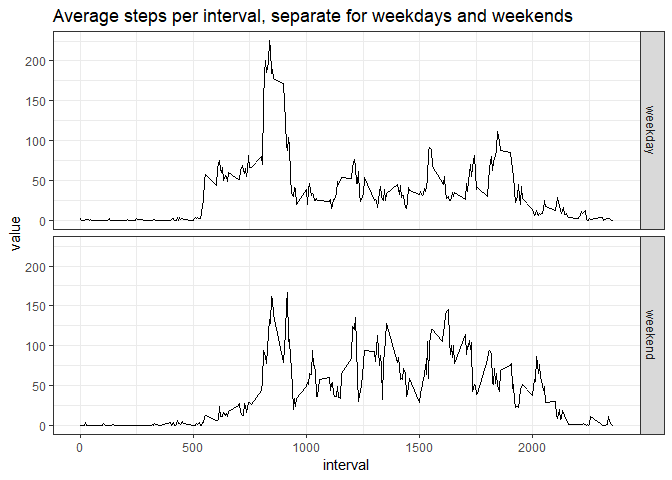

```r
intervalsteps_fix_long <- melt(intervalsteps_fix, id = c("interval","weekday"))  # convert to long format
ggplot(intervalsteps_fix_long, aes(x = interval, y = value, group=weekday)) +
        theme_bw()+facet_grid(weekday ~ .)+geom_line()+
        labs(title = "Average steps per interval, separate for weekdays and weekends")
```